# Precursor_Ion_Scan_XCMS

2026-05-27

# Precursor ion scanning of putative strigolactones

In this markdown, we aim at automatizing the detection of peaks from tandem MS data generated using a precursor-ion scan method. This method uses a fixed m/z on the MS2 detector to scan for precursors of a particular fragment. Here we use 97 m/z as bait as it corresponds to the “D-ring” fragment commonly produced by strigolactones. The data used here is generated by a XEVO TQ XS (Waters) and converted to open source format in MSconvert (ProteoWizard). Detection of peaks from MS data can be done in different ways. The classical approach uses the centwave algorithm from XCMS using continuous wavelet transform (CWT) or massifquant to detect chromatographic peaks.

## I. Data import and conversion from Waters XEVO TQ XS

### a. Export and convert data

For this analysis, we need:

-Metadata of MS run setup exported from Masslynx to a .csv table -Experimental design metadata (including root weight if possible) -Raw mass spec files (.raw from Waters systems) in an open format such as .mzML or .NetCDF

1. Export your metadata by opening your project file in Mass lynx (yourproject.PRO/Data/SampleDB/.SPL) and copy/pasting the method to a blank excel table. Add the headers to the different columns in excel by copy/pasting this: File_Name Sample_ID File_Text MS_File MS_Tune_File Inlet_File Bottle Inject_Volume Sample_Type and export to .csv
2. Export the data (yourproject.PRO/Data/*.raw) from the MS computer and convert to open format using MassLynx Databridge (https://support.waters.com/KB_Inf/MassLynx/WKB57100_How_to_export_raw_data_files_to_an_open_file_format_using_a_post_run_process) or MSconvert (https://proteowizard.sourceforge.io/download.html) to a new folder. Don’t forget to use the centroiding option on MS convert.
3. Finally, put all these files into a folder of your choice containing a folder with your .raw data and your metadata .csv files.

### b. Load libraries

```r
library(xcms)
library(faahKO)
library(RColorBrewer)
library(pander)
library(magrittr)
library(pheatmap)
library(MSnbase)
library(SummarizedExperiment)
library(ggplot2)
library(foreach)
library(iterators)
library(dplyr)
library(ggpubr)
library(BiocParallel)
library(processx)
library(plotly)
library(htmltools)
library(scales)
library(tidyr)
library(rstatix)
library(purrr)
library(stringr)
```

```r
cbPalette <- c("#E69F00", "#56B4E9", "#009E73", "#F0E442", "#0072B2", "#D55E00", "#CC79A7", "#999999")

cbPalette_ordered <- c( "#1f77b4", "#6baed6", "#08306b", "#54278f", "#d73027", "#fdae61", "#f46d43","#FFD700" ,"#3ff000", "#a6d96a", "#66bd63", "#1a9850", "#006837","#808080","#000000", "pink")
```

### c. Import data

Create a new object with the converted data and for the phenodata (metadata) file as follow:

```r
# Set path to metadata directory

PATH <- "/zfs/omics/personal/sjaupit/results/Strigolactone_ID/"

PATH_DATA <- "/zfs/omics/personal/sjaupit/results/Strigolactone_ID/Family_Experiment_PIS/"

# Import metadata

msetup <- read.csv(paste0(PATH,"MassLynx_Setup_FamExp.csv")) #MassLynx setup table

msetup <- msetup %>% dplyr::select(1:2)

meta <- read.csv(paste0(PATH,"Metadata_FamExp.csv")) #Experiment metadata

meta <- merge(msetup, meta, by = "SampleID")
```

```r
# Get the full path to the .mzML file

msfiles <- dir(path = paste0(PATH_DATA), pattern = ".mzML$",
                  full.names = TRUE)


# Create a phenodata object

pd_temp <- data.frame(File_Name = sub(basename(msfiles), pattern = ".mzML",
                                   replacement = "", fixed = TRUE),
                 stringsAsFactors = FALSE)


pd <- merge(pd_temp, meta, by="File_Name", all.x=TRUE)
```

RUN ONCE

The following step will take time, we save the resulting object in a .rds file to facilitate re-running the code if necessary.

```r
raw_data <- readMSData(files = msfiles, pdata = new("NAnnotatedDataFrame", pd),
                       mode = "onDisk")

#raw_data <- filterRt(raw_data, c(2500, 3500)) #OPTIONAL: set retention time range

head(rtime(raw_data))

saveRDS(raw_data, paste0(PATH,"raw_data_PIS_FamExp.rds")
```

## II. XCMS peak detection

We recommend the following XCMS tutorial if you are not familiar with this package:

https://jorainer.github.io/metabolomics2018/xcms-preprocessing.html

```r
raw_data <- readRDS(paste0(PATH,"raw_data_PIS_FamExp.rds"))

length(raw_data@processingData@files)
```

```
## [1] 609
```

### a. OPTIONAL - Pre-processing

```r
# Smooth the signal, then do a simple peak picking.
raw_data_cent <- smooth(raw_data, method = "SavitzkyGolay", halfWindowSize = 2L) %>%
    pickPeaks(refineMz = "descendPeak")

raw_data_cent <- smooth(raw_data, method = "MovingAverage", halfWindowSize = 2)
```

```r
# Define the mz and retention time ranges
serine_mz <- 106.049871
mzr <- c(serine_mz - 0.01, serine_mz + 0.01)
rtr <- c(175, 187)

# Filtering the object
serine <- raw_data_cent %>%
    filterRt(rtr) %>%
    filterMz(mzr)
```

The raw data were imported using the onDisk-mode that does not read the full MS data into memory. Any data manipulation (such as data smoothing or centroiding above) has to be applied on-the-fly to the data each time m/z or intensity values are retrieved.

To make any data manipulation on an OnDiskMSnExp object persistent we need to export the data to mzML files and re-read the data again. Below we thus save the centroided data as mzML files and import them again.

```r
# Write the centroided data to files with the same names in the current directory

fls_new <- basename(fileNames(raw_data_cent))

writeMSData(raw_data_cent, file = fls_new)

# Read the centroided data

data_cent <- readMSData(fls_new, pdata = new("NAnnotatedDataFrame", pd),
                        mode = "onDisk")

raw_data <- data_cent
```

### b. Initial data inspection

#### MS1

Define colors for the group variable (Species here).

```r
cbPalette_ordered <- c( "#1f77b4", "#6baed6", "#08306b", "#54278f", "#d73027", "#fdae61", "#f46d43","#FFD700" ,"#3ff000", "#a6d96a", "#66bd63", "#1a9850", "#006837", "#00CD66","#808080","#000000","pink",'#CD00CD', 'green','moccasin',"grey","lightgrey","#8B8878","#E0EEE0","#838B83","#9FB6CD", "#E69F00", "#56B4E9")

order <- c("CuS","CuSh","CuMa","CuM","CuMe","CiLm","CiL","CiLv","LS","CbT","CbF","CbP","CbA","CbM","LC","GP","Control","BLANK","QC","ZM","AT","NB","PS","MT","BO","BD", "P+", "P-")



group_colors <- setNames(
  rep(cbPalette_ordered, length.out = length(order)),
  order
)
```

```r
bpis1 <- chromatogram(raw_data, aggregationFun = "max", msLevel = 1L)
```

Plot all chromatograms.

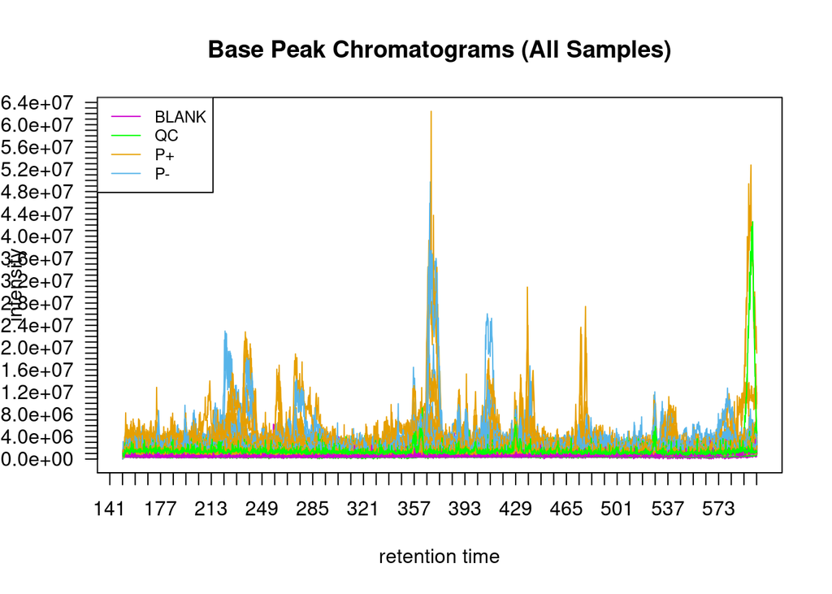

```r
plot(bpis1,
     col = group_colors[bpis1$Treatment],
     xaxp  = c(60, 600, 60),
     yaxp  = c(0, 100000000, 100),
     las = 1,
     lwd = 1,
     main = "Base Peak Chromatograms (All Samples)")

legend("topleft", legend=unique(bpis1$Treatment), col = group_colors[bpis1$Treatment], cex=0.8, lwd = 1)
```

#### TIC

Here, we look at the TIC per samples and per runs. We can identify failing MS runs and samples.

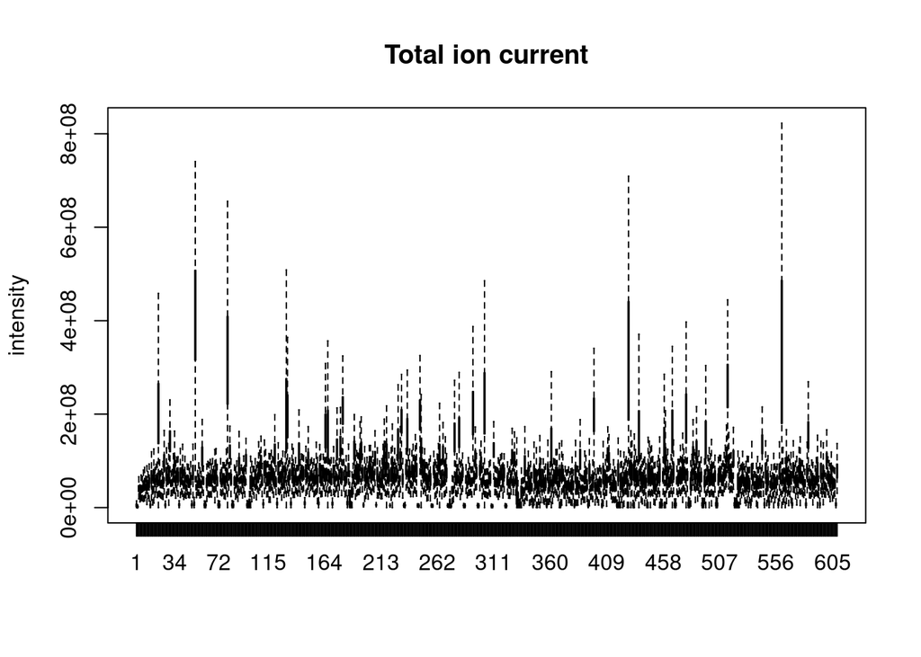

```r
tc <- split(tic(raw_data), f = fromFile(raw_data))
boxplot(tc, col = group_colors[raw_data$Treatment],
        ylab = "intensity", main = "Total ion current", outline = FALSE)
```

### c. Filtering samples

Filter blanks, QC and +P samples.

```r
filt_pd <- pd[!grepl("BLANK", pd$Treatment),]
filt_pd <- filt_pd[!grepl("QC", filt_pd$Treatment),]
filt_pd <- filt_pd[!grepl("P[\\+]", filt_pd$Treatment),]
filt_pd <- filt_pd[!grepl("NA", filt_pd$Treatment),]

vector_key <- list(filt_pd$File_Name)
pattern <- unlist(vector_key)

pattern <- paste0(pattern, sep= ".mzML", collapse = "|")

filtcdfs <- list.files(path = paste0(PATH,"Family_Experiment_PIS/"), pattern = pattern, full.names = TRUE, recursive = TRUE)

filt_data <- readMSData(files = filtcdfs, pdata = new("NAnnotatedDataFrame", filt_pd),
                       mode = "onDisk")
```

OPTIONAL

```r
filt_data <- filterRt(filt_data, rt = c(177, 500))
```

```r
filt_data <- filterEmptySpectra(filt_data)
```

```r
bpis2 <- chromatogram(filt_data, aggregationFun = "max", msLevel = 1L)
```

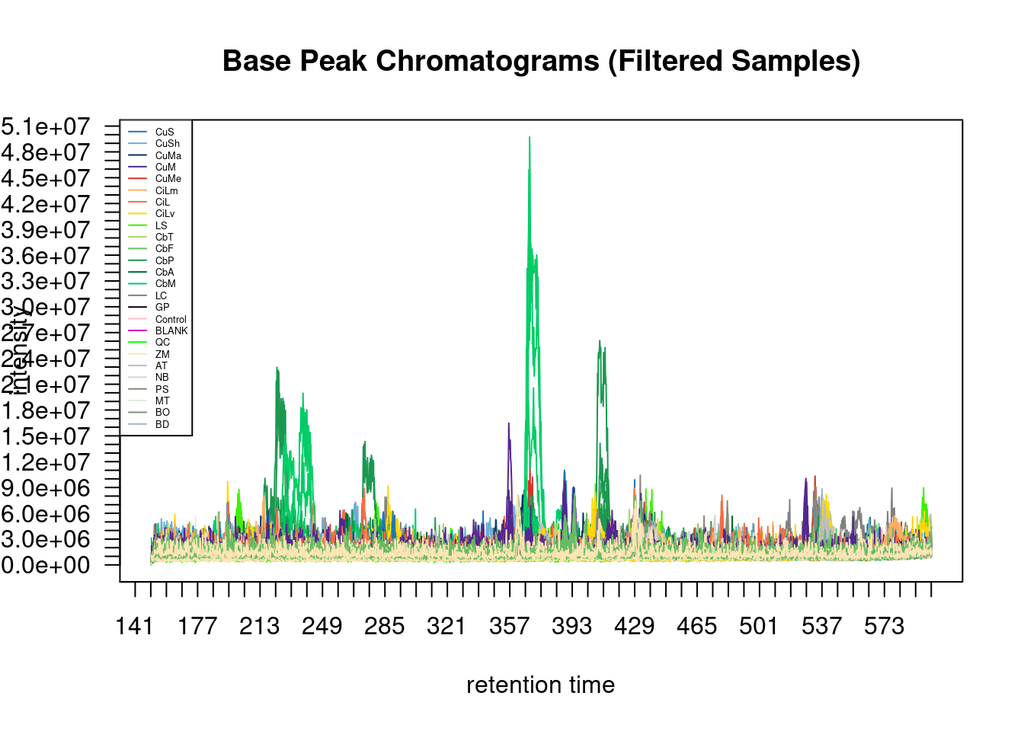

```r
group_colors2 <- group_colors[!names(group_colors) %in% c("P+","P-")]

plot(
  bpis2,
  col = group_colors2[bpis2$Species],
  xaxp  = c(60, 600, 60),
  yaxp  = c(0, 100000000, 100),
  las = 1,
  lwd = 1,
  main = "Base Peak Chromatograms (Filtered Samples)"
)
legend(
  "topleft",
  legend = names(group_colors2),
  col = group_colors2,
  cex = 0.4,
  lwd = 1
)
```

### d. Peak detection

#### Calibration peak

This part is used to adjust the peak width and noise parameters. Here, we choose a peak from the MS1 chromatogram, it is recommended to test several peaks.

```r
rtr <- c(360, 380) # Define the rentention time range of the peak area
mzr <- c(200, 500) # Define the m/z range of the peaks

chr_rawFam <- chromatogram(filt_data, mz = mzr, rt = rtr, msLevel = 1L)
```

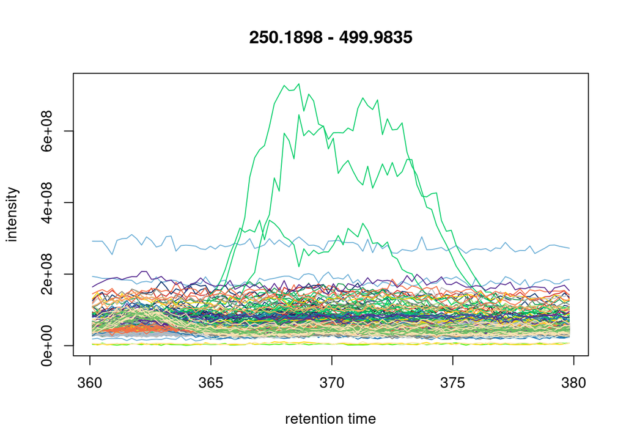

```r
plot(chr_rawFam, col =  group_colors[chr_rawFam$Species])
```

```r
filt_data %>%
    filterRt(rt = rtr) %>%
    filterMz(mz = mzr) %>%
    plot(type = "XIC", layout = NULL)
```

#### Run findChromPeaks function in all chromatograms

This step is the most sensitive, the values of peak width, noise and prefilter must be optimised. We recommend reading the following vignette: https://rdrr.io/bioc/xcms/man/findChromPeaks-centWave.html

Two peak-picking strategies are tested:

- `CentWaveParam`: classical continuous wavelet transform peak detection,
- `MassifquantParam`: Kalman-filter-based peak detection.

We define the following parameters as follow:

- **Peak width**: expected peak width in seconds.
- **Noise**: value to assign to base noise.
- **Prefilter**: `c(k, I)` with `k` = minimum number of peaks and `I` = intensity.
- **snthresh**: signal-to-noise ratio threshold.
- **integrate**: mexican hat = `1` or real data = `2`.

```r
#Set parameters

cwp <- CentWaveParam(peakwidth = c(2, 20), noise = 50000, prefilter = c(1, 1000), snthresh = 7, integrate= 1, fitgauss = TRUE)

mqp <- MassifquantParam(peakwidth = c(2, 20), noise = 20000000,
                     prefilter = c(1, 100000), snthresh = 20, integrate= 1, fitgauss = TRUE)

#Save parameters

saveRDS(cwp, file= paste0(PATH, "Centwave_SLs_FamExp.rds"))

saveRDS(mqp, file=paste0(PATH, "MassifQuant_SLs_FamExp.rds"))

#Run peak

xdataFam_cwp <- findChromPeaks(filt_data, param= cwp) #CentWave peak picking

xdataFam_mqp <- findChromPeaks(filt_data, param= mqp) #massifquant peak picking
#Save peak files

saveRDS(xdataFam_cwp, file=paste0(PATH,"CentWave_Chrompeak_xdataFam.rds"))

saveRDS(xdataFam_mqp, file=paste0(PATH,"MassifQuant_Chrompeak_xdataFam.rds"))
```

## III. Select peak picking algorithm

Here, we select the peak picking algorithm to use and run all chunk below to generate putative peaks tables.

```r
xdataFam_cwp <- readRDS(file=paste0(PATH,"CentWave_Chrompeak_xdataFam.rds"))

xdataFam_mqp <- readRDS(file=paste0(PATH,"MassifQuant_Chrompeak_xdataFam.rds"))

#Select peaks here (check/uncheck both lines below to choose peak algorithm and set output files names)

xdataFam <- xdataFam_cwp
method <- "Centwave"

#xdataFam <- xdataFam_mqp
#method <- "MassifQuant"


#Add file names extensiong

xdataFam_raw <- xdataFam

head(chromPeaks(xdataFam))
```

```
##               mz    mzmin    mzmax      rt   rtmin   rtmax      into      intb
## CP00001 402.9562 402.9536 402.9575 159.364 156.520 159.974  543791.1  530166.9
## CP00002 387.4718 387.4652 387.4759 368.028 367.621 368.637 1629848.7 1619466.1
## CP00003 387.2669 387.2654 387.2688 368.434 368.028 369.044 2080199.1 2041102.5
## CP00004 404.4298 404.4284 404.4337 368.637 367.418 370.669 1184071.2 1139458.1
## CP00005 387.0576 387.0507 387.0598 373.920 372.091 374.529  992164.8  932028.3
## CP00006 392.5900 392.5900 392.5900 400.130 399.520 401.958  484133.2  470590.7
##              maxo sn sample
## CP00001  628176.5  9      1
## CP00002 3071932.0 41      1
## CP00003 2902030.0 12      1
## CP00004 1141578.0 11      1
## CP00005 1327944.0  7      1
## CP00006  679040.0 11      1
```

### a. Putative peaks pre-processing

Here, we remove failed samples if needed. **Be careful to adjust sample numbers to remove between test runs !**

```r
keep_files <- setdiff(1:length(fileNames(xdataFam)), 44) #Insert file to remove here

xdataFam <- filterFile(xdataFam, file = keep_files, keepAdjustedRtime = keepAdjustedRtime)

filt_pd <- xdataFam@phenoData@data

filt_pd$sample <- seq_len(nrow(filt_pd))

filt_pd <- filt_pd[-44,]

rownames(filt_pd) <- NULL
```

### b. OPTIONAL - Peak refining

```r
mpp <- MergeNeighboringPeaksParam(expandRt = 5, expandMz = 0.1, ppm = 10, minProp = 0.75)

xdataFam <- refineChromPeaks(xdataFam, mpp)
```

The aim of the gap filling step is to reduce the number of such missing values by integrating signals from the original data files for samples in which no chromatographic peak was found from the m/z - retention time region where signal from the ion is expected.

```r
pdFamp <- PeakDensityParam(sampleGroups = filt_pd$Species,
                        minFraction = 0.4, bw = 30)

xdataFam <- groupChromPeaks(xdataFam, param = pdFamp)
```

```r
xdataFam <- fillChromPeaks(xdataFam, param = ChromPeakAreaParam())

featureValues(xdataFam, value = "into") |> head()
```

Here we inspect peaks before and after optional pre-processing.

```r
mzr_1 <- mzr
rtr_1 <- rtr
chr_1 <- chromatogram(filterFile(xdataFam_raw, 14), mz = mzr_1, rt = rtr_1) #No preprocessing
chr_2 <- chromatogram(filterFile(xdataFam, 14), mz = mzr_1, rt = rtr_1) # Pre-processed
par(mfrow = c(1, 2))
plot(chr_1)
plot(chr_2)
```

### c. Print summary

```r
summary_fun <- function(z)
    c(peak_count = nrow(z), rt = quantile(z[, "rtmax"] - z[, "rtmin"]))

sumX <- lapply(split.data.frame(
    chromPeaks(xdataFam), f = chromPeaks(xdataFam)[, "sample"]),
    FUN = summary_fun)

sumX <- do.call(rbind, sumX)

sumX <- as.data.frame(sumX)

sumX$sample <- as.numeric(rownames(sumX))

sumX_annot <- merge(
    sumX,
    filt_pd[, c("sample", "SampleID")],
    by = "sample",
    all.x = TRUE
)

head(sumX_annot)
```

```
##   sample peak_count    rt.0%   rt.25%   rt.50%   rt.75%   rt.100% SampleID
## 1      1         26 1.015034 1.524267 2.336483 2.844000  3.453999  CuSh_L-
## 2      2         28 1.015978 1.168249 1.929989 2.641253 11.580992   CbA_I-
## 3      3         20 1.015005 1.016006 1.625519 2.235003  3.250980   CbA_A-
## 4      4         16 1.015949 1.016006 1.320477 2.082739  2.642012    LC_L-
## 5      5         45 1.014977 1.016006 1.827965 2.844000 14.425993    LS_F-
## 6      6         26 1.015005 1.016006 1.726999 3.555508  7.721014    GP_L-
```

## IV. Identification of putative SLs peaks

#### a. Inspection of indentified peaks

```r
xdataFam_pp <- xdataFam

putative_peaks_Fam_std <- as.data.frame(chromPeaks(xdataFam_pp))

head(chromPeaks(xdataFam_pp))
```

```
##               mz    mzmin    mzmax      rt   rtmin   rtmax      into      intb
## CP00001 402.9562 402.9536 402.9575 159.364 156.520 159.974  543791.1  530166.9
## CP00002 387.4718 387.4652 387.4759 368.028 367.621 368.637 1629848.7 1619466.1
## CP00003 387.2669 387.2654 387.2688 368.434 368.028 369.044 2080199.1 2041102.5
## CP00004 404.4298 404.4284 404.4337 368.637 367.418 370.669 1184071.2 1139458.1
## CP00005 387.0576 387.0507 387.0598 373.920 372.091 374.529  992164.8  932028.3
## CP00006 392.5900 392.5900 392.5900 400.130 399.520 401.958  484133.2  470590.7
##              maxo sn sample
## CP00001  628176.5  9      1
## CP00002 3071932.0 41      1
## CP00003 2902030.0 12      1
## CP00004 1141578.0 11      1
## CP00005 1327944.0  7      1
## CP00006  679040.0 11      1
```

Here we plot the chromatograms and signal to noise ratios of the peaks.

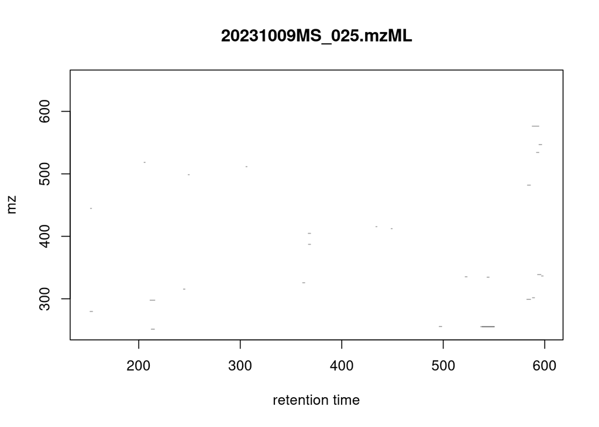

```r
plotChromPeaks(xdataFam_pp, file = 10)
```

```r
putative_peaks_Fam_std$sample <- as.character(putative_peaks_Fam_std$sample)
putative_peaks_Fam_std <- merge(filt_pd, putative_peaks_Fam_std , by = "sample")
```

### b. Peak filtering

Here we calculate the baseline threshold for the noise.

```r
x <- putative_peaks_Fam_std$into

h <- hist(x, breaks = 1000, plot = FALSE)

smooth_counts <- smooth.spline(h$mids, h$counts, spar = 0.7)

y <- predict(smooth_counts, h$mids)$y

peak_idx <- which.max(y)

dy <- diff(y)

min_idx <- which(diff(sign(dy)) == 2)
min_idx <- min_idx[min_idx > peak_idx][1]

baseline_threshold <- h$mids[min_idx]

baseline_threshold <- 0.75*baseline_threshold

print(baseline_threshold)
```

```
## [1] 4068750
```

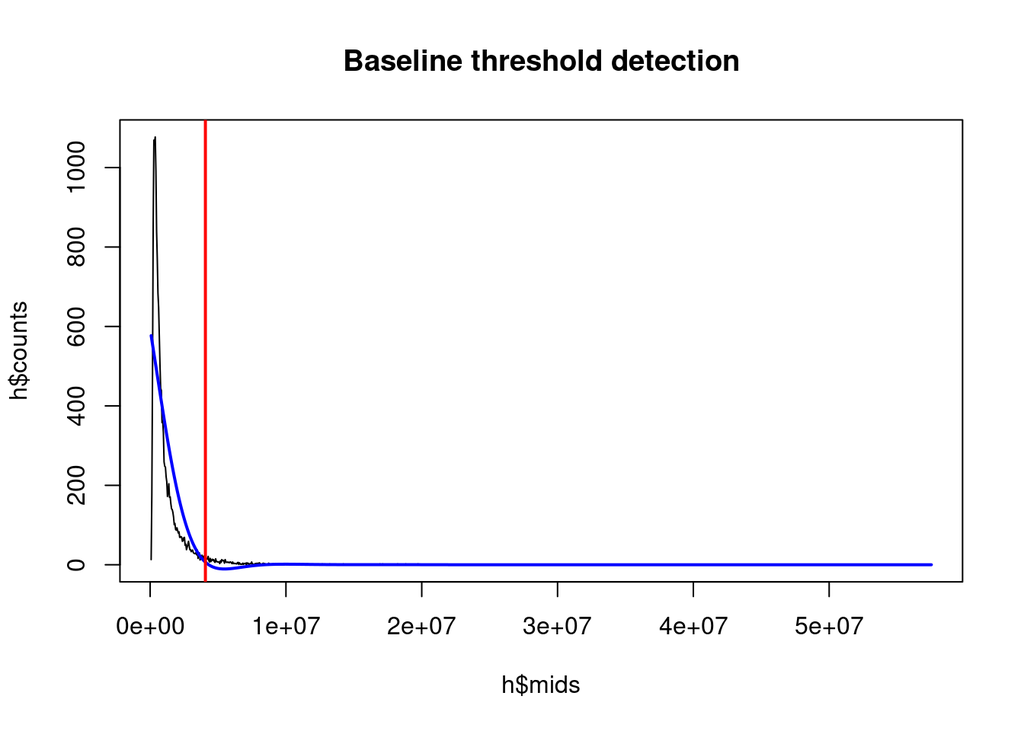

```r
plot(h$mids, h$counts, type = "l", main = "Baseline threshold detection")
lines(h$mids, y, col = "blue", lwd = 2)
abline(v = baseline_threshold, col = "red", lwd = 2)
```

Here we filter the peaks table to identify putative SLs peaks. This step is crucial to obtain meaningful peaks and different combination of parameters should be tested.

```r
putative_peaks_Fam_std$rmz <- round(putative_peaks_Fam_std$mz, digit=1)

putative_peaks_Fam_std$rrt <- (round(putative_peaks_Fam_std$rt, digit=0))/60

#putative_peaks_Fam_std_filt <- putative_peaks_Fam_std %>% filter(sn > 10) #signal/noise

putative_peaks_Fam_std_filt <- putative_peaks_Fam_std %>% filter(into > baseline_threshold)

#putative_peaks_Fam_std_filt <- putative_peaks_Fam_std_filt %>% filter(rmz < 420)
#putative_peaks_Fam_std_filt <- putative_peaks_Fam_std_filt %>% filter(rmz > 330)


putative_peaks_Fam_std_filt <- putative_peaks_Fam_std_filt %>% filter(Species != "CuSh")
#putative_peaks_Fam_std_filt <- putative_peaks_Fam_std_filt %>% filter(Species != "CuM")
#putative_peaks_Fam_std_filt <- putative_peaks_Fam_std_filt %>% filter(Species != "CuMa")



#putative_peaks_Fam_std_filt <-  putative_peaks_Fam_std_filt %>% group_by(rmz, rrt) %>% filter(n()>1) #remove low occurrence peaks

guests <- as.vector(c("BD", "AT", "BO", "PS", "MT","NB", "SL", "ZM"))

putative_peaks_Fam_std_filt <- putative_peaks_Fam_std_filt[!putative_peaks_Fam_std_filt$Species %in% guests,]
```

### c. Plot peaks

Plot filtered peaks pre-filtering.

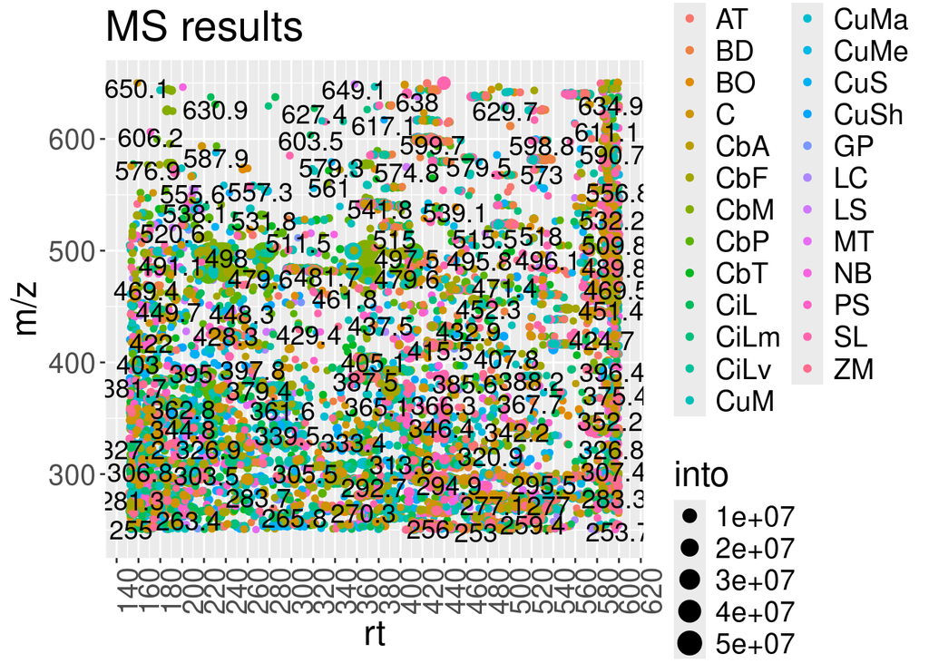

```r
plot1 <- ggplot(putative_peaks_Fam_std, aes(x=rt, y=rmz, color=Species, size = into))+geom_count()+labs( y = "m/z", title ="MS results")  + theme(axis.text.x = element_text(angle = 90)) + theme(text = element_text(size = 19))+
  geom_text(aes(label = rmz), color= "#000000" , nudge_y = -5, check_overlap = TRUE, size = 5)  +
scale_x_continuous(breaks = scales::pretty_breaks(n = 20))

plot1
```

Here we normalize peak intensities by root weight before plotting.

```r
putative_peaks_Fam_std_filt_combined <- as.data.frame(putative_peaks_Fam_std_filt)


putative_peaks_Fam_std_filt_combined$norm <- putative_peaks_Fam_std_filt_combined[,"into"]/putative_peaks_Fam_std_filt_combined[,"Weight"]

names(putative_peaks_Fam_std_filt_combined)[names(putative_peaks_Fam_std_filt_combined) == 'into'] <- 'Intensity'
```

Plot putative peaks post-filtering.

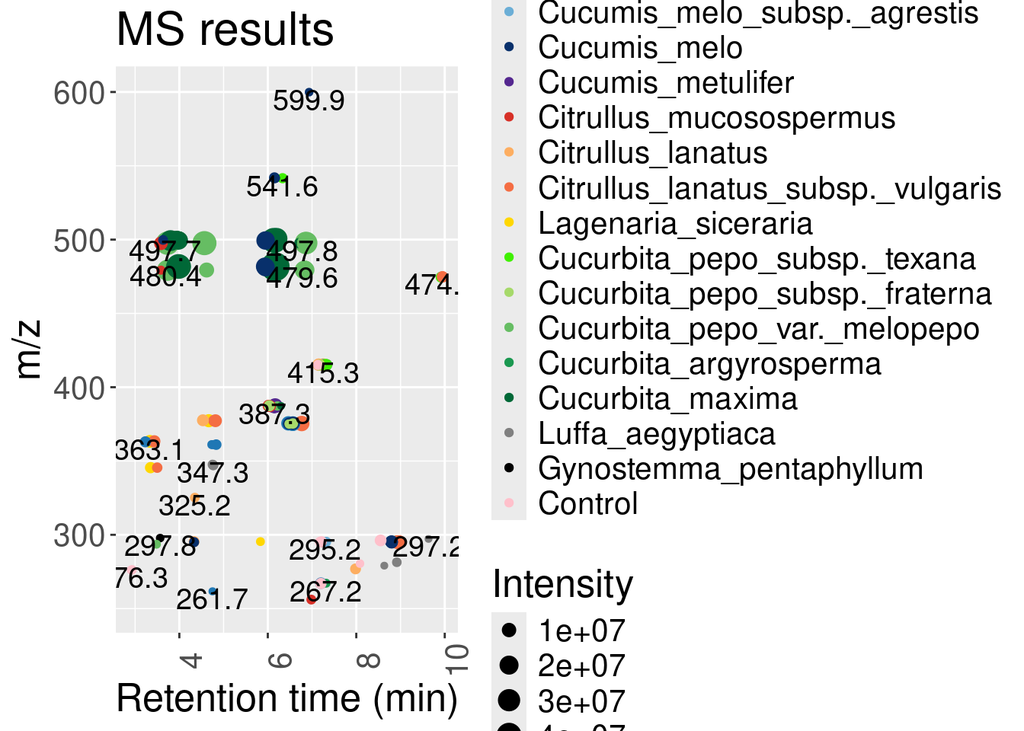

```r
cbPalette_ordered <- c( "#1f77b4", "#6baed6", "#08306b", "#54278f", "#d73027", "#fdae61", "#f46d43","#FFD700" ,"#3ff000", "#a6d96a", "#66bd63", "#1a9850", "#006837","#808080","#000000", "pink")


order <- c(
  "Cucumis_sativus",
  "Cucumis_sativus_var._hardwickii",
  "Cucumis_melo_subsp._agrestis",
  "Cucumis_melo",
  "Cucumis_metulifer",
  "Citrullus_mucosospermus",
  "Citrullus_lanatus",
  "Citrullus_lanatus_subsp._vulgaris",
  "Lagenaria_siceraria",
  "Cucurbita_pepo_subsp._texana",
  "Cucurbita_pepo_subsp._fraterna",
  "Cucurbita_pepo_var._melopepo",
  "Cucurbita_argyrosperma",
  "Cucurbita_maxima",
  "Luffa_aegyptiaca",
  "Gynostemma_pentaphyllum",
  "Control"
)

putative_peaks_Fam_std_filt_combined$Latin <- factor(putative_peaks_Fam_std_filt_combined$Latin, levels = order)

plot2 <- ggplot(putative_peaks_Fam_std_filt_combined, aes(x=rrt, y=rmz, color=Latin, size = Intensity))+geom_count()+labs( y = "m/z", title ="MS results", color = "Species")  + theme(axis.text.x = element_text(angle = 90)) + theme(text = element_text(size = 19))+ scale_color_manual(values = cbPalette_ordered) +
  geom_text(aes(label = rmz), color= "#000000" , nudge_y = -5, check_overlap = TRUE, size = 5) + xlab("Retention time (min)")


plot2
```

```r
ggsave(plot2, file = paste0(PATH,"Putative_Peaks_Cucurb_",method,".png"), width = 12, height = 7)
```

```r
figFamExfilt <- plot_ly(putative_peaks_Fam_std_filt_combined, x = ~rrt, y = ~rmz, z = ~Intensity, color = ~Latin, colors = cbPalette_ordered) %>%
  config(
    edits = list(
      annotationPosition = TRUE,
      annotationTail = TRUE,
      annotationText = TRUE
    ),
    toImageButtonOptions = list(format = "svg")
  )

figFamExfilt
```

[interactive chart not shown]

### d. Peak binning and control filtering

Here, we bin peaks by retention times and m/z and highlight peaks found in control pots without plants.

```r
#Set parameters

rt_bin_size  <- 0.16  # retention time window
mz_bin_size  <- 2     # m/z window

control_name <- "C"   # control label
min_presence <- 0.05   # minimum fraction of replicates containing signal
control_max  <- 0.05  # maximum fraction allowed in controls

# Prepare data

dat <- putative_peaks_Fam_std_filt_combined %>%
  mutate(
    rmz = as.numeric(rmz),
    rrt = as.numeric(rrt),

    # RT bins
    rt_bin = floor(rrt / rt_bin_size) * rt_bin_size + (rt_bin_size),

    # MZ bins
    mz_bin = floor(rmz / mz_bin_size) * mz_bin_size + (mz_bin_size/2),

    feature_bin = paste0(
      "RT_", round(rt_bin, 2),
      "_MZ_", round(mz_bin, 1)
    )
  )


feature_summary <- dat %>%
  group_by(
    SampleID,
    Species,
    feature_bin,
    Latin,
    rt_bin,
    mz_bin
  ) %>%
  summarise(
    intensity = mean(maxo, na.rm = TRUE),
    detected  = any(maxo > 0, na.rm = TRUE),
    .groups = "drop"
  )


# Remove features in control samples

feature_presence <- feature_summary %>%
  group_by(feature_bin, Species) %>%
  summarise(
    n_samples = n(),
    prevalence = mean(detected),
    mean_intensity = mean(intensity, na.rm = TRUE),
    .groups = "drop"
  )

# Presence in controls

control_features <- feature_presence %>%
  dplyr::filter(Species == control_name) %>%
  dplyr::select(feature_bin, control_prev = prevalence)

control_features
```

```
## # A tibble: 7 × 2
##   feature_bin    control_prev
##   <chr>                 <dbl>
## 1 RT_3.04_MZ_277            1
## 2 RT_7.2_MZ_295             1
## 3 RT_7.2_MZ_415             1
## 4 RT_7.36_MZ_267            1
## 5 RT_7.36_MZ_295            1
## 6 RT_8.16_MZ_281            1
## 7 RT_8.64_MZ_297            1
```

```r
# Presence in plants

treated_features <- feature_presence %>%
  filter(Species != control_name)

# Keep features that are absent in controls

selected_features <- treated_features %>%
  left_join(control_features, by = "feature_bin") %>%
  mutate(control_prev = replace_na(control_prev, 0)) %>%
  dplyr::filter(
    prevalence >= min_presence,
    control_prev <= control_max
  ) %>%
  pull(feature_bin) %>%
  unique()

feature_filtered <- feature_summary %>%
  filter(feature_bin %in% selected_features)

feature_filtered <- as.data.frame(feature_filtered)

feature_filtered <- feature_filtered[
    order(feature_filtered$rt_bin, decreasing = FALSE),
]

# Unique mass transitions and RT

unique_features <- unique(
  feature_filtered[, c("feature_bin", "rt_bin", "mz_bin")]
)

rownames(unique_features) <- NULL

print(unique_features)
```

```
##        feature_bin rt_bin mz_bin
## 1   RT_3.36_MZ_363   3.36    363
## 2   RT_3.36_MZ_345   3.36    345
## 3   RT_3.52_MZ_293   3.52    293
## 4   RT_3.52_MZ_345   3.52    345
## 5   RT_3.52_MZ_363   3.52    363
## 6   RT_3.68_MZ_479   3.68    479
## 7   RT_3.68_MZ_497   3.68    497
## 8   RT_3.68_MZ_499   3.68    499
## 9   RT_3.68_MZ_297   3.68    297
## 10  RT_3.84_MZ_501   3.84    501
## 11  RT_3.84_MZ_481   3.84    481
## 12  RT_3.84_MZ_499   3.84    499
## 13  RT_3.84_MZ_479   3.84    479
## 14  RT_3.84_MZ_497   3.84    497
```

[output cut: 55 more lines]

[figure not shown]

```r
# Plot intensity of putative features

plot_data <- feature_filtered

plotArea <- ggplot(
  plot_data,
  aes(
    x = feature_bin,
    y = intensity
  )
) +
  geom_boxplot(outlier.size = 0.4) +
  geom_jitter(width = 0.15, alpha = 0.4, size = 0.7) +
  labs(
    title = "Differential RT/MZ Features",
    x = "",
    y = "Peak Intensity"
  ) +
  theme_bw(base_size = 14) +
  theme(
    axis.text.x = element_text(angle = 45, hjust = 1),
    strip.text = element_text(size = 8)
  )

plotArea
```

```r
# Summary tables

feature_presence_table <- plot_data %>%
  group_by(
    feature_bin,
    Latin,
    Species
  ) %>%
  summarise(
    n_samples = n_distinct(SampleID),
    mean_intensity = mean(intensity, na.rm = TRUE),
    max_intensity = max(intensity, na.rm = TRUE),
    detected = any(intensity > 0, na.rm = TRUE),
    .groups = "drop"
  ) %>%
  filter(detected)

# Print long-format table
print(feature_presence_table)
```

```
## # A tibble: 114 × 7
##    feature_bin     Latin Species n_samples mean_intensity max_intensity detected
##    <chr>           <fct> <chr>       <int>          <dbl>         <dbl> <lgl>
##  1 RT_10.08_MZ_475 Citr… CiLv            4       3465456.       3724296 TRUE
##  2 RT_10.08_MZ_475 Cucu… CbT             1       2444860        2444860 TRUE
##  3 RT_10.08_MZ_475 Cucu… CbP             2       3364840        3684844 TRUE
##  4 RT_3.36_MZ_345  Lage… LS              2       5296490        6609248 TRUE
##  5 RT_3.36_MZ_363  Cucu… CuS             1       5961224        5961224 TRUE
##  6 RT_3.36_MZ_363  Lage… LS              2       5865215        5957152 TRUE
##  7 RT_3.52_MZ_293  Cucu… CbP             1       2317032        2317032 TRUE
##  8 RT_3.52_MZ_345  Citr… CiLv            1       2330790        2330790 TRUE
##  9 RT_3.52_MZ_363  Citr… CiLv            1       4129521        4129521 TRUE
## 10 RT_3.52_MZ_363  Lage… LS              2       5429439        7245132 TRUE
## # ℹ 104 more rows
```

```r
feature_presence_table <- as.data.frame(feature_presence_table)


feature_presence_wide <- feature_presence_table %>%
  mutate(present = "YES") %>%
  unite(group, Latin,  sep = " | ") %>%
  dplyr::select(feature_bin, group, present) %>%
  pivot_wider(
    names_from = group,
    values_from = present,
    values_fill = "-"
  )

print(feature_presence_wide)
```

```
## # A tibble: 69 × 16
##    feature_bin     Citrullus_lanatus_subsp._vulgaris Cucurbita_pepo_subsp._tex…¹
##    <chr>           <chr>                             <chr>
##  1 RT_10.08_MZ_475 YES                               YES
##  2 RT_3.36_MZ_345  -                                 -
##  3 RT_3.36_MZ_363  -                                 -
##  4 RT_3.52_MZ_293  -                                 -
##  5 RT_3.52_MZ_345  YES                               -
##  6 RT_3.52_MZ_363  YES                               -
##  7 RT_3.68_MZ_297  -                                 -
##  8 RT_3.68_MZ_479  -                                 -
##  9 RT_3.68_MZ_497  -                                 -
## 10 RT_3.68_MZ_499  -                                 -
## # ℹ 59 more rows
## # ℹ abbreviated name: ¹Cucurbita_pepo_subsp._texana
## # ℹ 13 more variables: Cucurbita_pepo_var._melopepo <chr>,
## #   Lagenaria_siceraria <chr>, Cucumis_sativus <chr>,
## #   Gynostemma_pentaphyllum <chr>, Citrullus_mucosospermus <chr>,
## #   Cucumis_melo <chr>, Cucurbita_maxima <chr>,
## #   Cucumis_melo_subsp._agrestis <chr>, Citrullus_lanatus <chr>, …
```

```r
feature_presence_wide <- as.data.frame(feature_presence_wide)
```

### e. Save outputs

```r
htmlwidgets::saveWidget(as_widget(figFamExfilt), paste0(PATH,"figFamExfilt_",method,".html"))
write.csv(putative_peaks_Fam_std, paste0(PATH,"putative_peaks_Fam_std_all_samples_",method,".csv"))

write.csv(putative_peaks_Fam_std_filt, paste0(PATH,"putative_peaks_Fam_std_filt_all_samples_",method,".csv"))

write.csv(putative_peaks_Fam_std_filt_combined, paste0(PATH,"putative_peaks_Fam_std_filt_combined_all_samples_",method,".csv"))

write.csv(feature_presence_table, paste0(PATH,"feature_presence_table_",method,".csv"))

write.csv(feature_presence_wide, paste0(PATH,"feature_presence_wide_",method,".csv"))

write.csv(feature_filtered, paste0(PATH,"putative_features_per_plants_",method,".csv"))

write.csv(unique_features, paste0(PATH,"putative_features_info_",method,".csv"))
```

### f. Compare methods

Here we compare features found by both peak picking algorithms.

```r
cwp_features <- read.csv(paste0(PATH,"putative_features_info_Centwave.csv"))

mqp_features <- read.csv(paste0(PATH,"putative_features_info_MassifQuant.csv"))

cwp_bin <- cwp_features$feature_bin
mqp_bin <- mqp_features$feature_bin

common_features <- intersect(cwp_bin, mqp_bin)

length(common_features)
```

```
## [1] 61
```

```r
common_mz <- sub(".*MZ_", "", common_features)

unique(common_mz)
```

```
##  [1] "363" "345" "497" "297" "501" "481" "499" "479" "483" "295" "377" "361"
## [13] "347" "387" "541" "375" "257" "599" "415" "277" "279" "281" "475"
```

```r
only_cwp <- setdiff(cwp_bin, mqp_bin)
only_mqp <- setdiff(mqp_bin, cwp_bin)


comparison <- list(
  common = common_features,
  only_cwp = only_cwp,
  only_mqp = only_mqp
)



cat("\n================ FEATURE COMPARISON SUMMARY ================\n\n")
```

```
##
## ================ FEATURE COMPARISON SUMMARY ================
```

```r
cat("- Common features (shared between methods):", length(common_features), "\n")
```

```
## - Common features (shared between methods): 61
```

```r
cat("- Unique to CentWave:", length(only_cwp), "\n")
```

```
## - Unique to CentWave: 8
```

```r
cat("- Unique to MassifQuant:", length(only_mqp), "\n\n")
```

```
## - Unique to MassifQuant: 90
```

```r
cat("- Unique m/z transitions in common features:", unique(common_mz), "\n\n")
```

```
## - Unique m/z transitions in common features: 363 345 497 297 501 481 499 479 483 295 377 361 347 387 541 375 257 599 415 277 279 281 475
```

```r
cat("============================================================\n")
```